# AV Explained and Exploited for Better Prediction

rareitmeyer

2017-05-16

# Summary

This script explains adversarial validation, shows important differences between the Kaggle-supplied test and training data, and gives you the test row IDs that can improve your prediction accuracy. Along the way, it illustrates using XGBoost for classification, how to spot the most important features in a XGBoost model, and permutation testing.

# Validation Background

When building a model for a Kaggle contest, it’s easy to check accuracy by modeling against the entire ‘train’ dataset provided, then predicting on all the provided ‘test’ and using the leaderboard to see which model is best.

But that only works for less than five good ideas per day, and isn’t easy to add into a programmatic optimization routine.

The preferred approach is to break the supplied training data into two or three subsets. Names vary, but basically:

- train, used to train a model, ~60% of the overall train data
- test, used to pick hyperparameters, ~20% of the overall train data
- validation, used to chose between models, ~20% of the overall train data

By picking models based on the validation set, we can do all the model-picking work locally without any five-per-day limit. (Beware we will eventually start overfitting the validation set, but it happens indirectly.)

## But what happens if my validation set isn’t like the Kaggle ‘test’ set?

Using a local validation set is great… unless it isn’t. If the data set we are using to validate against “is not like” the data set Kaggle is using to score our entry, model-picking will go awry.

## Adversarial validation

Enter “Adversarial Validation.” Obligatory links:

- [http://fastml.com/adversarial-validation-part-one/]
- [http://fastml.com/adversarial-validation-part-two/]

Adversarial validation is a way to check to see if the validation set (or more broadly, the overall training data) is like the submission test data.

This is *good* in that it lets us know if using a randomly-picked test or validation data set for model picking will be helpful or misleading.

But it’s *great* because it provides a way to make new test / validation sets that should be like the submission test data, enabling us to use our test / validation results with confidence.

## Setup

Get started by loading libraries, defining some useful functions, loading the data and fixing data types.

(Have echo=FALSE to suppress this as it’s fairly boring, but look at the code if interested.)

## In adversarial validation, the response is test/train, not price.

The big idea is that we can compare whether or not the supplied training and submission test data are “the same” by fitting a powerful model try to predict whether a given point came from train or test.

If the model can’t do better than a random guess, then the two data sets are essentially identical. (Or our model was poor.)

So for adversarial validation, the goal isn’t to predict the response… it’s to predict whether or not the price is known. To that end, replace the response with a 0/1 train/test indicator.

```r
overall_data[,response_col] <- as.numeric(is.na(overall_data[,response_col]))
```

## No timestamp or macroeconomic features

Thinking ahead to avoid doing useless work, and keep this presentation shorter, we’re not going to use the timestamp or macroecomic features.

If we keep the timestamp and macroeconomic indicators, we’d have complete separation, because all of the train data is 2015-06-30 or earlier and all test data is 2015-07-01 or later. The timestamp is a direct giveaway.

Other macroeconomic columns like cpi or deposits value or fixed basket are fairly unique to the before / after 2015-06-30 cutoff and are also giveaways.

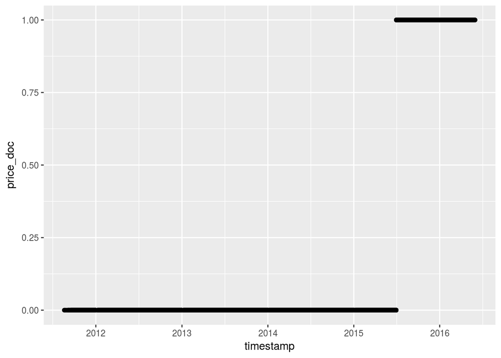

```r
ggplot2::qplot(timestamp, price_doc, data=overall_data)
```

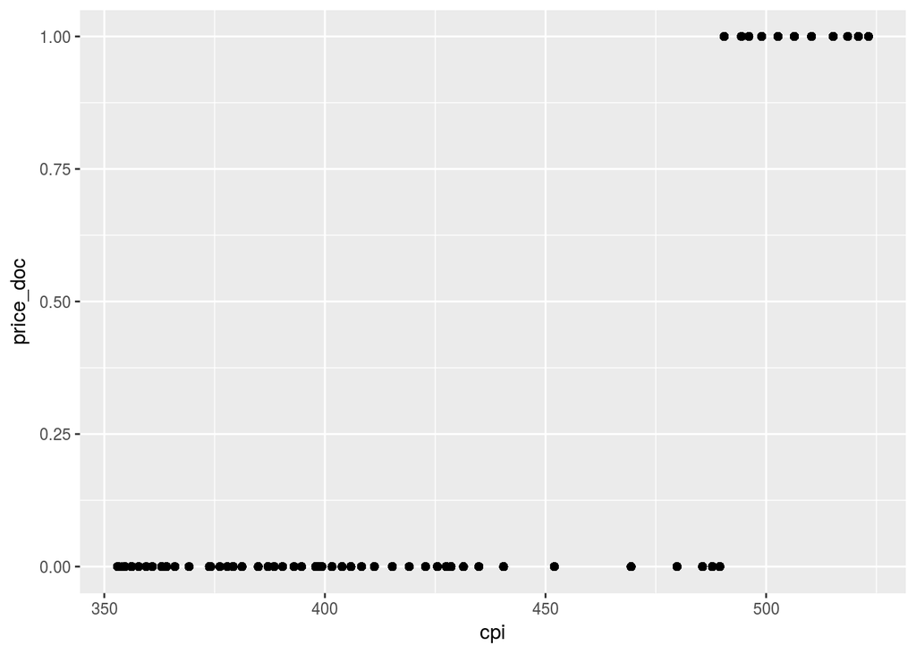

```r
ggplot2::qplot(cpi, price_doc, data=merge(overall_data, macro, by='timestamp'))
```

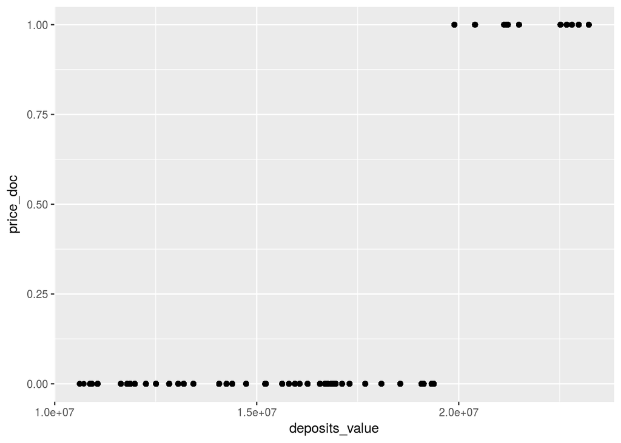

```r
ggplot2::qplot(deposits_value, price_doc, data=merge(overall_data, macro, by='timestamp'))
```

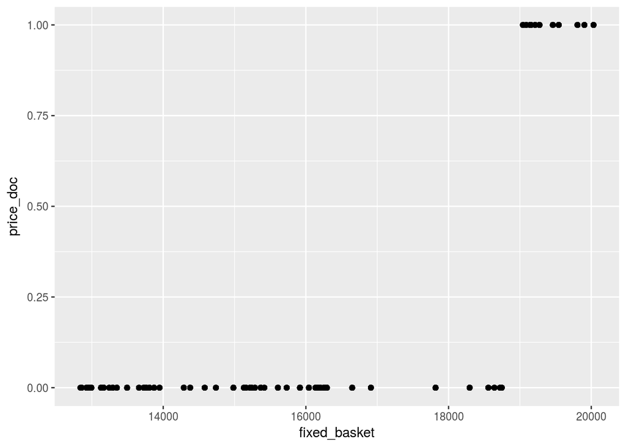

```r
ggplot2::qplot(fixed_basket, price_doc, data=merge(overall_data, macro, by='timestamp'))
```

## Predictor columns

The predictor columns are the ones we’ll model on. As above, omit the response column, the timestamp, and the ID since that is another giveaway. If we’d merged in macroeconomic columns, we’d omit those too.

But take all the other columns.

```r
predictor_cols <- setdiff(names(overall_data), c(response_col,'timestamp','id'))
```

Now build random splits for train / test / validation sets, per typical practice typically outside of adversarial validation. We’ll be able to see how well those are predicted by the upcoming model as a check.

Make XGBoost matricies, too. (Here “to X” is utility function skipped over above.)

```r
# partition repeatably by setting a seed to contest end-date as an integer.
set.seed(20170529)

train_idx <- caret::createDataPartition(overall_data[1:nrow(overall_data),response_col], p=0.6, list=FALSE)
non_train <- overall_data[setdiff(1:nrow(overall_data), train_idx),]
train <- overall_data[train_idx,]
validation_idx <- caret::createDataPartition(non_train[,response_col], p=0.5, list=FALSE)
validation <- non_train[validation_idx,]
test <- non_train[-c(validation_idx),]

X_train <- to_X(train[,predictor_cols], label=train[,response_col])
X_test <- to_X(test[,predictor_cols], label=test[,response_col])
X_validation <- to_X(validation[,predictor_cols], label=validation[,response_col])
```

Make a model with XGBoost. Note that this is a classification problem, not a regression problem, so the objective is binary:logistic and the eval metric is logloss. (Don’t accidentally copy-paste linear regression code when doing adversarial validation!)

```r
param <- list(objective="binary:logistic",
              eval_metric = "logloss",
              eta = .02,
              gamma = 1,
              max_depth = 4,
              min_child_weight = 1,
              subsample = .7,
              colsample_bytree = .5
)
rounds = 300
xgb_model <- xgb.train(data = X_train$X,
                       params = param,
                       watchlist = list(train = X_train$X),
                       nrounds = rounds,
                       verbose = 1,
                       print.every.n = 25
)
```

# Predictions

So, check the predictions for our in-sample (train) data set and test / validation data sets. Are the test and validation data sets roughly in line with random guessing, which would mean the Kaggle submission test data is “the same as” the overall training data?

Compare f1 scores from the predictor and random guessing with same proportion of train/test points. The latter is easily obtained by permuting.

```r
library(ModelMetrics, quiet=TRUE)
score_fn <- function(actual, predicted)
{
  return (ModelMetrics::f1Score(actual, predicted))
}
train_preds <- predict(xgb_model, X_train$X)
print(sprintf('train score: %f', score_fn(train[,response_col],train_preds)))
```

```
## [1] "train score: 0.751165"
```

```r
train_random_guess <- sample(train[,response_col])
print(sprintf('train random guess score: %f', score_fn(train[,response_col],train_random_guess)))
```

```
## [1] "train random guess score: 0.203611"
```

```r
test_preds <- predict(xgb_model, X_test$X)
print(sprintf('test score: %f', score_fn(test[,response_col],test_preds)))
```

```
## [1] "test score: 0.737731"
```

```r
test_random_guess <- sample(test[,response_col])
print(sprintf('test random guess score: %f', score_fn(test[,response_col],test_random_guess)))
```

```
## [1] "test random guess score: 0.203156"
```

```r
valid_preds <- predict(xgb_model, X_validation$X)
print(sprintf('validation score: %f', score_fn(validation[,response_col],valid_preds)))
```

```
## [1] "validation score: 0.746730"
```

```r
valid_random_guess <- sample(validation[,response_col])
print(sprintf('test random guess score: %f', score_fn(validation[,response_col],valid_random_guess)))
```

```
## [1] "test random guess score: 0.205959"
```

## Feature Importances

OK, the model did find a discrepancy between the test and train sets, even after excluding obvious columns like id, timestamp, and any macroeconomic columns that would proxy for timestamp.

We can see what it found by looking at the top feature importances.

In XGBoost, the ‘Gain’ is the most important number, bigger meaning more important.

```r
# importances are ordered by Gain, biggest gain (most important) first
importances <- xgb.importance(feature_names=X_train$names, model=xgb_model)
head(importances,10)
```

```
##                        Feature       Gain       Cover   Frequence
##  1:                   kitch_sq 0.54039692 0.324541753 0.290000000
##  2:         max_floor_isnaTRUE 0.11097101 0.108819435 0.045000000
##  3:          num_room_isnaTRUE 0.06475696 0.063864569 0.026153846
##  4:                 build_year 0.04664257 0.076769558 0.059230769
##  5:          kitch_sq_isnaTRUE 0.03680863 0.029880120 0.011153846
##  6:                    life_sq 0.02165941 0.052338945 0.047307692
##  7:                    full_sq 0.01539745 0.025147873 0.029615385
##  8: ID_railroad_station_walk19 0.01327090 0.037449673 0.018846154
##  9:              industrial_km 0.01248865 0.026218754 0.024615385
## 10:        build_year_isnaTRUE 0.01052595 0.009466896 0.004230769
```

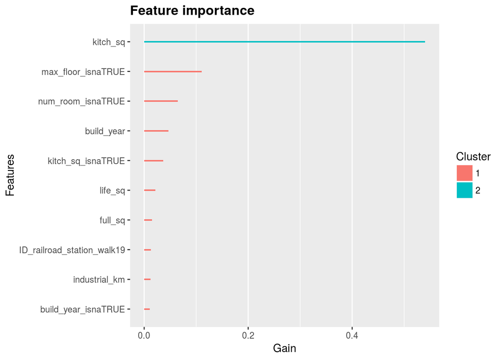

```r
xgb.plot.importance(importances[1:10,])
```

Looks like kitchen square meters and NA for max floors are pretty different between the overall train data and the submission test data.

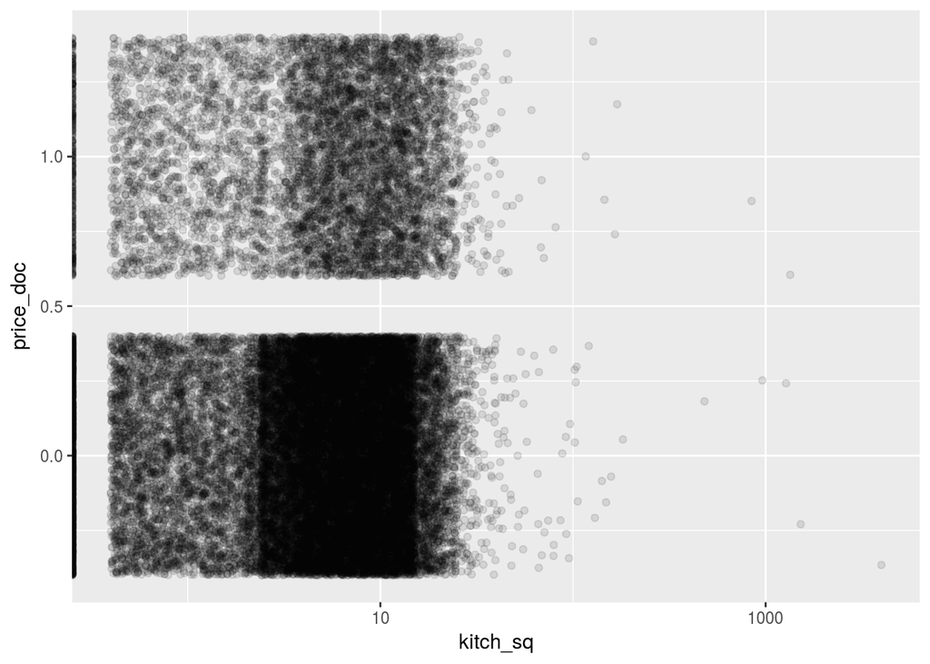

```r
ggplot2::ggplot(aes(x=kitch_sq, y=price_doc), data=overall_data)+geom_jitter(width=0.4, alpha=0.1)+scale_x_log10()
```

And if a record has max_floor as NA, it’s always a train record and not a submission test record.

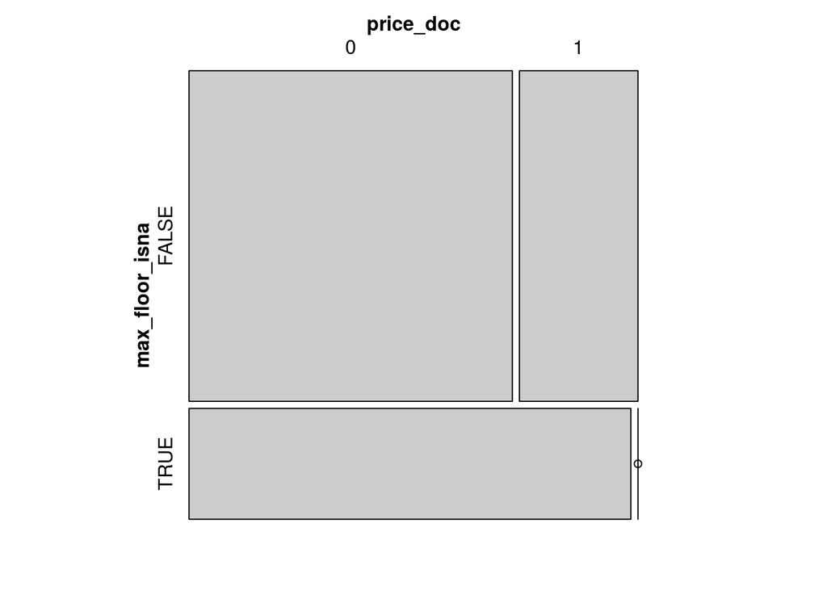

```r
vcd::mosaic(xtabs(~max_floor_isna + price_doc, data=overall_data))
```

It’s certainly possible to records with the number of rooms missing, or the build year, but it’s not really needed.

## Make new train / test / validation sets the easy way

While we could make a series of graphs like the above and then try to use them to pick data that is suitable for using as a test / validation set, there is a better way.

We’ll use the model we built to predict how “test”-like each record of the overall training data is. Sort on the prediction column, and the top N rows are our top-N test like records!

So instead of partioning the provided training data randomly into train / test / validation, use the top portion of this table to grab your test and validation, and the bottom portion as your training, to improve the accuracy of your local model optimization.

```r
overall_train <- subset(overall_data, price_doc == 0)
X_overall_train <- to_X(overall_train[,predictor_cols])
overall_train_preds <- predict(xgb_model, X_overall_train$X)
overall_train_ids_by_testprob <- data.frame(id=overall_train$id, testprob=overall_train_preds)
overall_train_ids_by_testprob <- overall_train_ids_by_testprob[order(overall_train_ids_by_testprob$testprob, decreasing=TRUE),]

save(overall_train_ids_by_testprob, file='overall_train_ids_by_testprob.Rdata')
write.csv(overall_train_ids_by_testprob, file='overall_train_ids_by_testprob.csv', row.names=FALSE)
```

## Final thoughts.

Good luck! I hope this helps you improve your scores.

And if you can spare this an up-vote…

## Postscript 2015-05-19

Happycube asked if I’d tried omitting all the pre-2015 data, on grounds the early data was more ID-able than the later.

That seemed worth a graph.

Below is a EDCF plot showing the (cumulative) proportion of data points for each value of test probability.

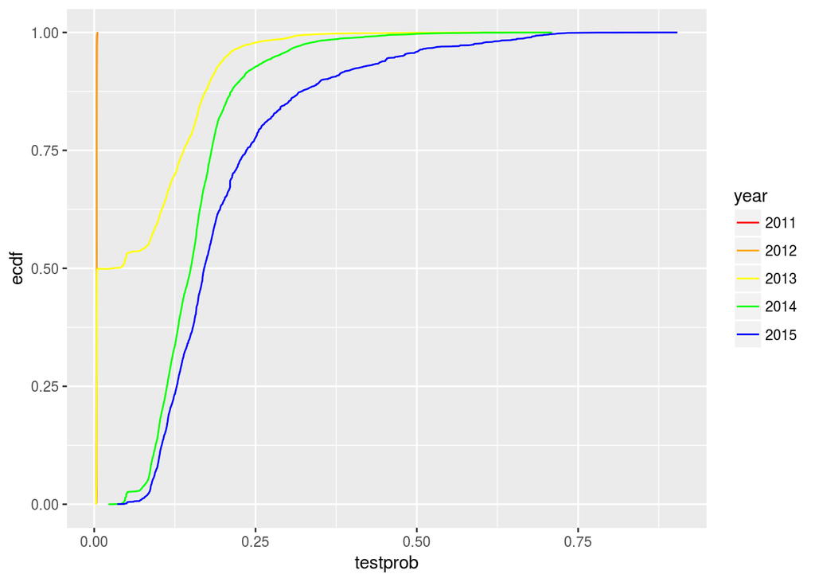

```r
if (file.exists('overall_train_ids_by_testprob.Rdata')) {
    load('overall_train_ids_by_testprob.Rdata')
}
train <- read.csv(input_filename('train.csv'))
train$timestamp <- as.Date(train$timestamp)
train$year <- lubridate::year(train$timestamp)
testprob_by_year <- merge(train[,c('id','year')], overall_train_ids_by_testprob[,c('id','testprob')])

testprob_by_year_ecdf <- do.call(
    rbind, lapply(
        with(testprob_by_year, min(year):max(year)), function(y) {
            s <- subset(testprob_by_year, year == y)
            ecdf_fn <- ecdf(s$testprob)
            s$ecdf <- ecdf_fn(s$testprob)
            s$year <- ordered(s$year)
            return (s)
        }))
ggplot(aes(x=testprob, y=ecdf, group=year), data=testprob_by_year_ecdf)+geom_line(aes(color=year))+scale_color_manual(values=c('red', 'orange', 'yellow', 'green', 'blue'))
```

My take on this is that discarding 2011 and 2012 is sensible, but I’d keep 2014. 2013 is a toss up, as keeping gives 50% more data to train on, but the data isn’t especially relevant to the submission test set.

Thanks, happycube!